# Food Insecurity Across U.S. Counties and Census Tracts

**Author:** Nabaa Al Hashimi  
**Live site:** [Food insecurity project site](https://nabaahashimi.github.io/food_insecurity_project/)

# Introduction & Motivation

Food insecurity refers to the limited or uncertain availability of nutritious, affordable food. It does not only describe whether people have food in the moment, but whether they can reliably access healthy food options that support long-term well-being. Across the United States, food insecurity is strongly shaped by structural factors such as neighborhood poverty, access to transportation, distance to supermarkets, and broader socioeconomic conditions. These factors often combine to produce “food deserts,” where residents must travel long distances usually without a personal vehicle to reach a grocery store.

To study these issues at a meaningful level of detail, this project uses census tracts as the primary unit of analysis. A census tract is a small, relatively permanent geographic region defined by the U.S. Census Bureau, typically containing 2,500–8,000 residents. Tracts are designed to represent neighborhoods with similar demographic and socioeconomic characteristics. Census tracts allow for a more precise analysis of community-level differences in income, transportation access, and food availability.

A key metric in this project is the “low-access” population, defined by the USDA Food Access Research Atlas. A resident is considered low-access if they live beyond a reasonable distance from a supermarket: urban tracts (more than 1 mile from a supermarket) and rural tracts (more than 10 miles from a supermarket)

**Why this matters for data science:** Understanding food insecurity requires integrating heterogeneous datasets (tract-level, county-level, health outcomes, socioeconomic indicators) and using data science tools to clean, merge, visualize, and model them. This tutorial demonstrates real-world challenges in data wrangling, geographic identifiers (FIPS), multi-scale data alignment, exploratory analysis, and predictive modeling. Food insecurity is a spatial, structural, and statistical problem—making it a rich data science case study.

The project focuses on the following research questions:

- How is census-tract or county-level food insecurity distributed across the United States, and what does the variation in its distribution reveal about geographic inequality?
- What is the relationship between structural food-access barriers and food insecurity at the county level?
- How do socioeconomic and geographic factors shape food insecurity rates across U.S. counties?

Addressing these questions through data cleaning, integration, exploratory analysis, and early modeling will prepare the foundation for building predictive models in the next milestone.

# Data Sources

This project integrates three large public datasets to analyze neighborhood-level food access and broader county-level food insecurity conditions across the United States.

1. USDA Food Access Research Atlas (Census Tract Level)
- Unit: Census tract
- Source: USDA ERS
- Purpose: Measures physical access to supermarkets and identifies low-access populations.
- Link: https://www.ers.usda.gov/data-products/food-access-research-atlas/
2. USDA Food Environment Atlas (County Level)
- Unit: County
- Source: USDA ERS
- Purpose: Describes socioeconomic and community factors shaping county-level food security.
- Link: https://www.ers.usda.gov/data-products/food-environment-atlas/
3. CDC PLACES (Census Tract & County Level)
- Unit: Census tract & county
- Source: Centers for Disease Control and Prevention
- Purpose: Provides modeled health-related measures for small-area surveillance, including Food Insecurity (Crude Prevalence).
- Link: https://www.cdc.gov/places/

Together, the USDA Food Access Atlas, USDA Food Environment Atlas, and CDC PLACES datasets provide tract and county-level measures of food access, socioeconomic conditions, and modeled food insecurity prevalence to allow for analysis of the structural and geographic factors shaping food insecurity across the U.S.

## ETL: USDA Food Access Research Atlas (Census Tract Level)

In this section, I load and clean the USDA Food Access Research Atlas data.  
This file provides tract-level information on food access, including: distance to supermarkets,low-income and low-access populations, households without vehicles, and basic tract identifiers.

Since my outcome and other predictors will be at the county level, I will:

1. Load the tract-level data.
2. Select key variables related to food access.
3. Standardize geographic identifiers (Census tract and county FIPS).
4. Handle missing values and compute tract-level food-access rates.
5. Aggregate tract-level counts into county-level totals and rates.

First I will mount my drive and load the dataset in

```python
# mount google drive to upload datasets
from google.colab import drive
drive.mount('/content/drive')
```

```python
import pandas as pd
import numpy as np
import matplotlib.pyplot as plt

# load in file
fa_path = "drive/My Drive/Food_Access_2019.xlsx"

# Read the sheet that has the data
fa_raw = pd.read_excel(fa_path, sheet_name="Food Access Research Atlas")

# Check the first few rows of data
fa_raw.head()
```

|  | CensusTract | State | County | Urban | Pop2010 | OHU2010 | GroupQuartersFlag | NUMGQTRS | PCTGQTRS | LILATracts_1And10 | ... | TractSeniors | TractWhite | TractBlack | TractAsian | TractNHOPI | TractAIAN | TractOMultir | TractHispanic | TractHUNV | TractSNAP |
| --- | --- | --- | --- | --- | --- | --- | --- | --- | --- | --- | --- | --- | --- | --- | --- | --- | --- | --- | --- | --- | --- |
| 0 | 1001020100 | Alabama | Autauga County | 1 | 1912 | 693 | 0 | 0.0 | 0.000000 | 0 | ... | 221.0 | 1622.0 | 217.0 | 14.0 | 0.0 | 14.0 | 45.0 | 44.0 | 6.0 | 102.0 |
| 1 | 1001020200 | Alabama | Autauga County | 1 | 2170 | 743 | 0 | 181.0 | 8.341014 | 1 | ... | 214.0 | 888.0 | 1217.0 | 5.0 | 0.0 | 5.0 | 55.0 | 75.0 | 89.0 | 156.0 |
| 2 | 1001020300 | Alabama | Autauga County | 1 | 3373 | 1256 | 0 | 0.0 | 0.000000 | 0 | ... | 439.0 | 2576.0 | 647.0 | 17.0 | 5.0 | 11.0 | 117.0 | 87.0 | 99.0 | 172.0 |
| 3 | 1001020400 | Alabama | Autauga County | 1 | 4386 | 1722 | 0 | 0.0 | 0.000000 | 0 | ... | 904.0 | 4086.0 | 193.0 | 18.0 | 4.0 | 11.0 | 74.0 | 85.0 | 21.0 | 98.0 |
| 4 | 1001020500 | Alabama | Autauga County | 1 | 10766 | 4082 | 0 | 181.0 | 1.681219 | 0 | ... | 1126.0 | 8666.0 | 1437.0 | 296.0 | 9.0 | 48.0 | 310.0 | 355.0 | 230.0 | 339.0 |

5 rows × 147 columns

### 1. Select core tract-level variables

Based on the data, I will focus on the following variables:

- **CensusTract, State, County, Urban** – geographic identifiers and urban/rural context
- **Pop2010** – total tract population (needed to compute rates)
- **lapop1, lapop1share** – number and share of residents with low access
- **lalowi1, lalowi1share** – number and share of low-income residents with low access
- **lahunv1, lahunv1share** – number and share of low-access households without vehicles

These capture the main food-access barriers (distance, income, transportation) that I will later relate to food insecurity so I will select these variables now.

```python
# Keep only the columns needed for this project
fa = fa_raw[[
    "CensusTract",
    "State",
    "County",
    "Urban",
    "Pop2010",
    "lapop1", "lapop1share",
    "lalowi1", "lalowi1share",
    "lahunv1", "lahunv1share"
]].copy()

fa.head()
```

|  | CensusTract | State | County | Urban | Pop2010 | lapop1 | lapop1share | lalowi1 | lalowi1share | lahunv1 | lahunv1share |
| --- | --- | --- | --- | --- | --- | --- | --- | --- | --- | --- | --- |
| 0 | 1001020100 | Alabama | Autauga County | 1 | 1912 | 1896.493338 | 99.188982 | 460.998748 | 24.110813 | 5.490446 | 0.792272 |
| 1 | 1001020200 | Alabama | Autauga County | 1 | 2170 | 1260.991651 | 58.110214 | 603.892737 | 27.829158 | 66.903537 | 9.004514 |
| 2 | 1001020300 | Alabama | Autauga County | 1 | 3373 | 1551.703935 | 46.003674 | 478.260886 | 14.179095 | 0.000000 | 0.000000 |
| 3 | 1001020400 | Alabama | Autauga County | 1 | 4386 | 1363.466885 | 31.086796 | 343.215663 | 7.825255 | 7.941380 | 0.461172 |
| 4 | 1001020500 | Alabama | Autauga County | 1 | 10766 | 2643.095161 | 24.550392 | 586.413137 | 5.446899 | 55.211883 | 1.352569 |

### 2. Standardize geographic identifiers and data types

The dataset uses 11-digit Census tract codes, where the first 5 digits are the county FIPS code. I:

- Convert `CensusTract` to an 11-character zero-padded string.
- Extract the first 5 digits as `county_fips`.
- Ensure population and count variables are numeric so I can compute rates.

```python
# Ensure CensusTract is an 11-character, zero-padded string
fa["CensusTract"] = fa["CensusTract"].astype(str).str.zfill(11)

# Extract first 5 digits as county FIPS (string)
fa["county_fips"] = fa["CensusTract"].str[:5]

# Columns that should be numeric
num_cols = [
    "Pop2010",
    "lapop1", "lapop1share",
    "lalowi1", "lalowi1share",
    "lahunv1", "lahunv1share"
]

for col in num_cols:
    fa[col] = pd.to_numeric(fa[col], errors="coerce")

fa.dtypes.head(15)
```

|  | 0 |
| --- | --- |
| CensusTract | object |
| State | object |
| County | object |
| Urban | int64 |
| Pop2010 | int64 |
| lapop1 | float64 |
| lapop1share | float64 |
| lalowi1 | float64 |
| lalowi1share | float64 |
| lahunv1 | float64 |
| lahunv1share | float64 |
| county_fips | object |

**dtype:** object

### 3. Handle missing values

To keep computed rates meaningful:

- I drop tracts with missing `Pop2010` (population is required for any rate).
- I fill missing low-access counts (`lapop1`, `lalowi1`, `lahunv1`) with 0.
- I then recompute the share variables as counts divided by population, so they are consistent and reflect the cleaned counts.

```python
# Check missing values before cleaning
fa.isna().sum().sort_values(ascending=False)

# Drop tracts with missing population
fa_clean = fa.dropna(subset=["Pop2010"]).copy()

# Fill missing low-access counts with 0
for col in ["lapop1", "lalowi1", "lahunv1"]:
    fa_clean[col] = fa_clean[col].fillna(0)

# Recompute share variables from counts / population
fa_clean["lapop1share"]   = fa_clean["lapop1"]   / fa_clean["Pop2010"]
fa_clean["lalowi1share"]  = fa_clean["lalowi1"]  / fa_clean["Pop2010"]
fa_clean["lahunv1share"]  = fa_clean["lahunv1"]  / fa_clean["Pop2010"]

# Confirm missing values after cleaning
fa_clean.isna().sum().sort_values(ascending=False)
```

|  | 0 |
| --- | --- |
| CensusTract | 0 |
| State | 0 |
| County | 0 |
| Urban | 0 |
| Pop2010 | 0 |
| lapop1 | 0 |
| lapop1share | 0 |
| lalowi1 | 0 |
| lalowi1share | 0 |
| lahunv1 | 0 |
| lahunv1share | 0 |
| county_fips | 0 |

**dtype:** int64

### 4. Create tract-level food-access rate variables

I summarize food-access barriers at the tract level using three rates:

- `low_access_rate`: share of residents with low access
- `low_income_low_access_rate`: share of residents who are both low-income and low-access
- `no_vehicle_low_access_rate`: share of residents in low-access households without a vehicle

These will later be aggregated to the county level.

```python
# Tract-level rates
fa_clean["low_access_rate"] = fa_clean["lapop1"] / fa_clean["Pop2010"]
fa_clean["low_income_low_access_rate"] = fa_clean["lalowi1"] / fa_clean["Pop2010"]
fa_clean["no_vehicle_low_access_rate"] = fa_clean["lahunv1"] / fa_clean["Pop2010"]

# Preview a few columns
fa_clean[[
    "CensusTract",
    "county_fips",
    "Pop2010",
    "lapop1",
    "low_access_rate",
    "low_income_low_access_rate",
    "no_vehicle_low_access_rate"
]].head()
```

|  | CensusTract | county_fips | Pop2010 | lapop1 | low_access_rate | low_income_low_access_rate | no_vehicle_low_access_rate |
| --- | --- | --- | --- | --- | --- | --- | --- |
| 0 | 01001020100 | 01001 | 1912 | 1896.493338 | 0.991890 | 0.241108 | 0.002872 |
| 1 | 01001020200 | 01001 | 2170 | 1260.991651 | 0.581102 | 0.278292 | 0.030831 |
| 2 | 01001020300 | 01001 | 3373 | 1551.703935 | 0.460037 | 0.141791 | 0.000000 |
| 3 | 01001020400 | 01001 | 4386 | 1363.466885 | 0.310868 | 0.078253 | 0.001811 |
| 4 | 01001020500 | 01001 | 10766 | 2643.095161 | 0.245504 | 0.054469 | 0.005128 |

### 5. Aggregate tract-level data to the county level

The Food Environment Atlas and CDC PLACES datasets are defined at the county level.  
To merge with those sources later, I aggregate tract-level counts into county-level totals:

- `total_pop`: sum of tract populations in the county
- `total_low_access`: total residents with low access
- `total_low_income_low_access`: total low-income residents with low access
- `total_no_vehicle_low_access`: total low-access residents in households without a vehicle

Then I convert these totals into county-level rates by dividing by `total_pop`.

```python
# Each row in fa_clean is a census tract; aggregate by county_fips
fa_county = fa_clean.groupby("county_fips").agg(
    total_pop=("Pop2010", "sum"),
    total_low_access=("lapop1", "sum"),
    total_low_income_low_access=("lalowi1", "sum"),
    total_no_vehicle_low_access=("lahunv1", "sum")
).reset_index()

# County-level rates
fa_county["low_access_rate_county"] = (
    fa_county["total_low_access"] / fa_county["total_pop"]
)

fa_county["low_income_low_access_rate_county"] = (
    fa_county["total_low_income_low_access"] / fa_county["total_pop"]
)

fa_county["no_vehicle_low_access_rate_county"] = (
    fa_county["total_no_vehicle_low_access"] / fa_county["total_pop"]
)

# Preview county-level dataset
fa_county.head()
```

|  | county_fips | total_pop | total_low_access | total_low_income_low_access | total_no_vehicle_low_access | low_access_rate_county | low_income_low_access_rate_county | no_vehicle_low_access_rate_county |
| --- | --- | --- | --- | --- | --- | --- | --- | --- |
| 0 | 01001 | 54571 | 37424.108778 | 12068.104362 | 833.360281 | 0.685787 | 0.221145 | 0.015271 |
| 1 | 01003 | 182265 | 132441.234727 | 38842.400894 | 1655.418161 | 0.726641 | 0.213109 | 0.009082 |
| 2 | 01005 | 27457 | 19005.932371 | 9290.490779 | 546.730871 | 0.692207 | 0.338365 | 0.019912 |
| 3 | 01007 | 22915 | 17559.934924 | 6479.391594 | 311.429872 | 0.766307 | 0.282758 | 0.013591 |
| 4 | 01009 | 57322 | 50848.320632 | 18188.154916 | 752.450353 | 0.887065 | 0.317298 | 0.013127 |

At this point, I have:

- **`fa_clean`** – a cleaned **tract-level** dataset with standardized FIPS codes and tract-level food-access rates.
- **`fa_county`** – an aggregated **county-level** dataset with total population, total low-access counts, and county-level food-access rates.

In the next ETL steps, I will merge `fa_county` with the USDA Food Environment Atlas and CDC PLACES datasets using `county_fips` as the county identifier.

## ETL: USDA Food Environment Atlas (County Level)

In this section, I process the USDA Food Environment Atlas data.  
This dataset provides county-level socioeconomic indicators such as poverty,income, age structure, and racial/ethnic composition.

I will use these variables to characterize the structural and demographic context of each county and later relate them to food insecurity and food access.

Steps in this ETL:

1. Load the Excel workbook and select the sheet with socioeconomic data.
2. Keep a focused subset of variables connected to poverty, income, age structure, and racial/ethnic composition.
3. Standardize the FIPS county code to a 5-digit string.
4. Ensure all socioeconomic variables are numeric and check for missing values.

```python
 # load in file
fe_path = "drive/My Drive/FoodEnvironmentAtlas.xlsx"

# Check sheet names
xls = pd.ExcelFile(fe_path)
xls.sheet_names
```

```
['Read_Me',
 ' Variable List',
 'ACCESS',
 'STORES',
 'RESTAURANTS',
 'ASSISTANCE',
 'INSECURITY',
 'TAXES',
 'LOCAL',
 'HEALTH',
 'SOCIOECONOMIC']
```

### 1. Load the socioeconomic sheet

The Excel file is organized into multiple topic-based sheets (e.g., **ACCESS**, **STORES**, **HEALTH**, **SOCIOECONOMIC**). I use the **SOCIOECONOMIC** sheet because it contains county-level indicators for:

- poverty and deep poverty,
- household income,
- age distribution,
- racial/ethnic composition, and
- metropolitan status / county stability.

The first row of this sheet contains descriptive labels, so I use `header=1` to treat the second row as the column names.

```python
# Load the socioeconmic sheet and use the second row (row index 1) as the header
fe_raw = pd.read_excel(fe_path, sheet_name="SOCIOECONOMIC", header=1)

#inspect available variables
fe_raw.columns[:50]
```

```
Index(['FIPS', 'State', 'County', 'PCT_NHWHITE20', 'PCT_NHBLACK20',
       'PCT_HISP20', 'PCT_NHASIAN20', 'PCT_NHNA20', 'PCT_NHPI20', 'PCT_NHOR20',
       'PCT_NHTMR20', 'PCT_65OLDER20', 'PCT_18YOUNGER20', 'MEDHHINC21',
       'POVRATE21', 'DEEPPOVRATE21', 'PERPOV17_21', 'CHILDPOVRATE21',
       'DEEPCHILDPOVRATE21', 'METRO23', 'POPLOSS15'],
      dtype='object')
```

### 2. Select relevant county-level variables

From the available columns, I keep a focused subset that aligns with my research questions. These variables capture:

- **Identifiers**
  - `FIPS`, `State`, `County` – county FIPS code and labels.
- **Racial/ethnic composition**
  - `PCT_NHWHITE20`, `PCT_NHBLACK20`, `PCT_HISP20`, `PCT_NHASIAN20`, `PCT_NHNA20`, `PCT_NHPI20`.
- **Age structure**
  - `PCT_65OLDER20` – share of population age 65+.
  - `PCT_18YOUNGER20` – share of population under 18.
- **Income & poverty**
  - `MEDHHINC21` – median household income.
  - `POVRATE21` – overall poverty rate.
  - `CHILDPOVRATE21` – child poverty rate.
  - `DEEPPOVRATE21`, `DEEPCHILDPOVRATE21` – deep poverty indicators.
  - `PERPOV17_21` – share of persons in poverty in 2017–2021.
- **Metro status & county change**
  - `METRO23` – metropolitan/non-metropolitan classification.
  - `POPLOSS15` – population loss indicator.

These will later be merged with county-level food access and food insecurity measures to model structural drivers of food insecurity.

```python
# List of columns to keep (if present)
selected_cols = [
    "FIPS", "State", "County",

    # Racial/ethnic composition
    "PCT_NHWHITE20", "PCT_NHBLACK20", "PCT_HISP20",
    "PCT_NHASIAN20", "PCT_NHNA20", "PCT_NHPI20",

    # Age structure
    "PCT_65OLDER20", "PCT_18YOUNGER20",

    # Income & poverty
    "MEDHHINC21", "POVRATE21", "CHILDPOVRATE21",
    "DEEPPOVRATE21", "DEEPCHILDPOVRATE21", "PERPOV17_21",

    # Metro status & county stability
    "METRO23", "POPLOSS15"
]

# Keep only columns that actually exist in the sheet
keep_cols = [c for c in selected_cols if c in fe_raw.columns]
print("Columns kept:", keep_cols)

fe = fe_raw[keep_cols].copy()
fe.head()
```

```
Columns kept: ['FIPS', 'State', 'County', 'PCT_NHWHITE20', 'PCT_NHBLACK20', 'PCT_HISP20', 'PCT_NHASIAN20', 'PCT_NHNA20', 'PCT_NHPI20', 'PCT_65OLDER20', 'PCT_18YOUNGER20', 'MEDHHINC21', 'POVRATE21', 'CHILDPOVRATE21', 'DEEPPOVRATE21', 'DEEPCHILDPOVRATE21', 'PERPOV17_21', 'METRO23', 'POPLOSS15']
```

|  | FIPS | State | County | PCT_NHWHITE20 | PCT_NHBLACK20 | PCT_HISP20 | PCT_NHASIAN20 | PCT_NHNA20 | PCT_NHPI20 | PCT_65OLDER20 | PCT_18YOUNGER20 | MEDHHINC21 | POVRATE21 | CHILDPOVRATE21 | DEEPPOVRATE21 | DEEPCHILDPOVRATE21 | PERPOV17_21 | METRO23 | POPLOSS15 |
| --- | --- | --- | --- | --- | --- | --- | --- | --- | --- | --- | --- | --- | --- | --- | --- | --- | --- | --- | --- |
| 0 | 1001 | AL | Autauga | 70.711674 | 19.304481 | 3.600034 | 1.484568 | 0.312899 | 0.037412 | 15.718051 | 24.287050 | 66444 | 10.7 | 16.1 | 6.250216 | 8.592895 | 0 | 1 | 0 |
| 1 | 1003 | AL | Baldwin | 80.466589 | 7.766852 | 5.473601 | 0.875448 | 0.557025 | 0.052639 | 21.871103 | 21.269637 | 65658 | 10.8 | 16.4 | 4.043401 | 5.503712 | 0 | 1 | 0 |
| 2 | 1005 | AL | Barbour | 43.951949 | 46.980930 | 5.986600 | 0.408357 | 0.229949 | 0.000000 | 20.231535 | 20.176030 | 38649 | 23.0 | 35.1 | 12.826966 | 26.729258 | 1 | 0 | 0 |
| 3 | 1007 | AL | Bibb | 73.754093 | 19.692280 | 3.319428 | 0.116629 | 0.174943 | 0.040371 | 16.220338 | 21.351994 | 48454 | 20.6 | 29.0 | 9.076190 | 17.513135 | 0 | 1 | 0 |
| 4 | 1009 | AL | Blount | 84.154632 | 1.396828 | 9.759191 | 0.294247 | 0.317922 | 0.018602 | 18.625495 | 23.220144 | 56894 | 12.0 | 16.7 | 5.291223 | 6.344746 | 0 | 1 | 0 |

### 3. Standardize FIPS codes and data types

To merge this dataset with other county-level sources, the `FIPS` code needs to be a 5-digit, zero-padded string

I also ensure that all socioeconomic variables (apart from identifiers) are stored as numeric values, which makes later analysis and modeling easier.

```python
# Convert FIPS to 5-character zero-padded string
fe["FIPS"] = fe["FIPS"].astype(str).str.zfill(5)

# Create a cleaned copy and convert all non-identifier columns to numeric
fe_clean = fe.copy()

for col in fe_clean.columns:
    # Do not convert identifier columns
    if col not in ["FIPS", "State", "County"]:
        fe_clean[col] = pd.to_numeric(fe_clean[col], errors="coerce")

# Check dtypes after conversion
fe_clean.dtypes
```

|  | 0 |
| --- | --- |
| FIPS | object |
| State | object |
| County | object |
| PCT_NHWHITE20 | float64 |
| PCT_NHBLACK20 | float64 |
| PCT_HISP20 | float64 |
| PCT_NHASIAN20 | float64 |
| PCT_NHNA20 | float64 |
| PCT_NHPI20 | float64 |
| PCT_65OLDER20 | float64 |
| PCT_18YOUNGER20 | float64 |
| MEDHHINC21 | int64 |
| POVRATE21 | float64 |
| CHILDPOVRATE21 | float64 |
| DEEPPOVRATE21 | float64 |
| DEEPCHILDPOVRATE21 | float64 |
| PERPOV17_21 | int64 |
| METRO23 | int64 |
| POPLOSS15 | int64 |

**dtype:** object

### 4. Check for missing values

Finally, I check for missing values in the cleaned dataset.  
In this case, the selected socioeconomic variables are complete, so no additional cleaning is required.

```python
# Count missing values in each column
fe_clean.isna().sum().sort_values(ascending=False)
```

|  | 0 |
| --- | --- |
| FIPS | 0 |
| State | 0 |
| County | 0 |
| PCT_NHWHITE20 | 0 |
| PCT_NHBLACK20 | 0 |
| PCT_HISP20 | 0 |
| PCT_NHASIAN20 | 0 |
| PCT_NHNA20 | 0 |
| PCT_NHPI20 | 0 |
| PCT_65OLDER20 | 0 |
| PCT_18YOUNGER20 | 0 |
| MEDHHINC21 | 0 |
| POVRATE21 | 0 |
| CHILDPOVRATE21 | 0 |
| DEEPPOVRATE21 | 0 |
| DEEPCHILDPOVRATE21 | 0 |
| PERPOV17_21 | 0 |
| METRO23 | 0 |
| POPLOSS15 | 0 |

**dtype:** int64

## ETL: CDC PLACES dataset (Census Tract & County Level)

The CDC PLACES dataset provides small-area estimates of many health-related outcomes. Each row corresponds to a geographic unit (census tract or county) and a specific health measure.

For this project, I use PLACES to obtain a **county-level outcome variable**:**Food insecurity in the past 12 months among adults**

This outcome will serve as my target variable when modeling how food access and socioeconomic characteristics relate to food insecurity.

In this ETL, I:

1. Load the raw CSV file and inspect its structure.
2. Explore the available measures and identify the food insecurity measure.
3. Filter to that measure, keeping only the most recent year and the `"Crude prevalence"` values.
4. Keep essential columns and clean the county FIPS identifier so it is ready to merge with my other county-level datasets.

```python
# Path to the CDC PLACES CSV file
cdc_path = "/content/drive/MyDrive/PLACES__Local_Data_for_Better_Health__Census_Tract_Data_2024_release.csv"

# Load the raw PLACES dataset
cdc = pd.read_csv(cdc_path)

# Inspect the first few rows
cdc.head()
```

|  | Year | StateAbbr | StateDesc | CountyName | CountyFIPS | LocationName | DataSource | Category | Measure | Data_Value_Unit | ... | Low_Confidence_Limit | High_Confidence_Limit | TotalPopulation | TotalPop18plus | Geolocation | LocationID | CategoryID | MeasureId | DataValueTypeID | Short_Question_Text |
| --- | --- | --- | --- | --- | --- | --- | --- | --- | --- | --- | --- | --- | --- | --- | --- | --- | --- | --- | --- | --- | --- |
| 0 | 2022 | FL | Florida | Miami-Dade | 12086 | 12086010025 | BRFSS | Health Outcomes | Stroke among adults | % | ... | 5.1 | 6.1 | 3992 | 3091 | POINT (-80.254741 25.9664383) | 12086010025 | HLTHOUT | STROKE | CrdPrv | Stroke |
| 1 | 2022 | FL | Florida | Miami-Dade | 12086 | 12086002709 | BRFSS | Disability | Vision disability among adults | % | ... | 2.8 | 3.4 | 5273 | 4706 | POINT (-80.1860897 25.793705) | 12086002709 | DISABLT | VISION | CrdPrv | Vision Disability |
| 2 | 2022 | FL | Florida | Miami-Dade | 12086 | 12086007807 | BRFSS | Disability | Vision disability among adults | % | ... | 4.0 | 4.8 | 4438 | 3489 | POINT (-80.3102933 25.6755601) | 12086007807 | DISABLT | VISION | CrdPrv | Vision Disability |
| 3 | 2022 | FL | Florida | Miami-Dade | 12086 | 12086001206 | BRFSS | Health Status | Frequent physical distress among adults | % | ... | 8.9 | 11.2 | 4835 | 4065 | POINT (-80.1708553 25.864528) | 12086001206 | HLTHSTAT | PHLTH | CrdPrv | Frequent Physical Distress |
| 4 | 2022 | FL | Florida | Miami-Dade | 12086 | 12086010018 | BRFSS | Disability | Any disability among adults | % | ... | 37.3 | 44.6 | 3577 | 2978 | POINT (-80.2873705 25.92881) | 12086010018 | DISABLT | DISABILITY | CrdPrv | Any Disability |

5 rows × 24 columns

### 1. Understand the structure of the PLACES file

PLACES is stored in a **long format**:

- Each row corresponds to one geographic unit (`LocationName`, `CountyFIPS`) and one health Measure.
- The 'Category' and `Measure` columns describe what is being measured.
- `Data_Value` contains the percentage estimate
- `Data_Value_Type` tells us how the value was calculated

Before selecting the food insecurity outcome, I explore the available variables and measures.

```python
# Show all column names to understand what is available
cdc.columns
```

```
Index(['Year', 'StateAbbr', 'StateDesc', 'CountyName', 'CountyFIPS',
       'LocationName', 'DataSource', 'Category', 'Measure', 'Data_Value_Unit',
       'Data_Value_Type', 'Data_Value', 'Data_Value_Footnote_Symbol',
       'Data_Value_Footnote', 'Low_Confidence_Limit', 'High_Confidence_Limit',
       'TotalPopulation', 'TotalPop18plus', 'Geolocation', 'LocationID',
       'CategoryID', 'MeasureId', 'DataValueTypeID', 'Short_Question_Text'],
      dtype='object')
```

```python
# High-level categories of measures
cdc["Category"].unique()
```

```
array(['Health Outcomes', 'Disability', 'Health Status',
       'Health Risk Behaviors', 'Health-Related Social Needs',
       'Prevention'], dtype=object)
```

```python
# Number of distinct measures included
cdc["Measure"].nunique()
```

```
40
```

```python
# Peek at the first 20 measure names (alphabetically) to see what is available
sorted(cdc["Measure"].unique())[:20]
```

```
['All teeth lost among adults aged >=65 years',
 'Any disability among adults',
 'Arthritis among adults',
 'Binge drinking among adults',
 'Cancer (non-skin) or melanoma among adults',
 'Cholesterol screening among adults',
 'Chronic obstructive pulmonary disease among adults',
 'Cognitive disability among adults',
 'Colorectal cancer screening among adults aged 45–75 years',
 'Coronary heart disease among adults',
 'Current asthma among adults',
 'Current cigarette smoking among adults',
 'Current lack of health insurance among adults aged 18-64 years',
 'Depression among adults',
 'Diagnosed diabetes among adults',
 'Fair or poor self-rated health status among adults',
 'Feeling socially isolated among adults',
 'Food insecurity in the past 12 months among adults',
 'Frequent mental distress among adults',
 'Frequent physical distress among adults']
```

### 2. Select the food insecurity outcome

From the list of measures, I focus on: **"Food insecurity in the past 12 months among adults"**

```python
# Name of the PLACES measure to use as the outcome
target_measure = "Food insecurity in the past 12 months among adults"

# Filter to only rows corresponding to this measure
cdc_target_rows = cdc[cdc["Measure"] == target_measure].copy()

# Inspect a few rows to confirm
cdc_target_rows.head()
```

|  | Year | StateAbbr | StateDesc | CountyName | CountyFIPS | LocationName | DataSource | Category | Measure | Data_Value_Unit | ... | Low_Confidence_Limit | High_Confidence_Limit | TotalPopulation | TotalPop18plus | Geolocation | LocationID | CategoryID | MeasureId | DataValueTypeID | Short_Question_Text |
| --- | --- | --- | --- | --- | --- | --- | --- | --- | --- | --- | --- | --- | --- | --- | --- | --- | --- | --- | --- | --- | --- |
| 36 | 2022 | FL | Florida | Miami-Dade | 12086 | 12086010502 | BRFSS | Health-Related Social Needs | Food insecurity in the past 12 months among ad... | % | ... | 18.2 | 22.3 | 9647 | 6820 | POINT (-80.3891204 25.5453193) | 12086010502 | SOCLNEED | FOODINSECU | CrdPrv | Food Insecurity |
| 40 | 2022 | FL | Florida | Miami-Dade | 12086 | 12086009602 | BRFSS | Health-Related Social Needs | Food insecurity in the past 12 months among ad... | % | ... | 37.0 | 43.0 | 3569 | 2766 | POINT (-80.1932388 25.9467009) | 12086009602 | SOCLNEED | FOODINSECU | CrdPrv | Food Insecurity |
| 83 | 2022 | FL | Florida | Miami-Dade | 12086 | 12086004303 | BRFSS | Health-Related Social Needs | Food insecurity in the past 12 months among ad... | % | ... | 22.2 | 26.6 | 2427 | 2116 | POINT (-80.129109 25.7824844) | 12086004303 | SOCLNEED | FOODINSECU | CrdPrv | Food Insecurity |
| 104 | 2022 | FL | Florida | Miami-Dade | 12086 | 12086003606 | BRFSS | Health-Related Social Needs | Food insecurity in the past 12 months among ad... | % | ... | 34.8 | 40.3 | 2007 | 1858 | POINT (-80.1993572 25.7753522) | 12086003606 | SOCLNEED | FOODINSECU | CrdPrv | Food Insecurity |
| 168 | 2022 | FL | Florida | Miami-Dade | 12086 | 12086003803 | BRFSS | Health-Related Social Needs | Food insecurity in the past 12 months among ad... | % | ... | 9.3 | 11.7 | 3093 | 2696 | POINT (-80.1231385 25.8928004) | 12086003803 | SOCLNEED | FOODINSECU | CrdPrv | Food Insecurity |

5 rows × 24 columns

### 3. Restrict to the most recent year and "Crude prevalence"

```python
# Check which years are available for this measure
cdc_target_rows["Year"].unique()
```

```
array([2022])
```

```python
# Check which data value types are available
cdc_target_rows["Data_Value_Type"].unique()
```

```
array(['Crude prevalence'], dtype=object)
```

```python
# Use the latest available year for this measure
latest_year = cdc_target_rows["Year"].astype(int).max()
latest_year
```

```
2022
```

```python
# Create a mask that keeps:
# the target measure
# the latest year
# "Crude prevalence" estimates
mask = (
    (cdc["Measure"] == target_measure) &
    (cdc["Year"].astype(int) == latest_year) &
    (cdc["Data_Value_Type"] == "Crude prevalence")
)

# Apply the mask and keep only columns needed for analysis
target_df = cdc.loc[mask, [
    "CountyFIPS",    # numeric county FIPS
    "StateAbbr",
    "StateDesc",
    "CountyName",
    "Data_Value",    # food insecurity percentage
    "Low_Confidence_Limit",
    "High_Confidence_Limit",
    "TotalPopulation"
]].copy()

target_df.head()
```

|  | CountyFIPS | StateAbbr | StateDesc | CountyName | Data_Value | Low_Confidence_Limit | High_Confidence_Limit | TotalPopulation |
| --- | --- | --- | --- | --- | --- | --- | --- | --- |
| 36 | 12086 | FL | Florida | Miami-Dade | 20.1 | 18.2 | 22.3 | 9647 |
| 40 | 12086 | FL | Florida | Miami-Dade | 40.0 | 37.0 | 43.0 | 3569 |
| 83 | 12086 | FL | Florida | Miami-Dade | 24.3 | 22.2 | 26.6 | 2427 |
| 104 | 12086 | FL | Florida | Miami-Dade | 37.5 | 34.8 | 40.3 | 2007 |
| 168 | 12086 | FL | Florida | Miami-Dade | 10.5 | 9.3 | 11.7 | 3093 |

### 4. Clean identifiers and rename the outcome variable

To merge this PLACES outcome with my county-level food access and socioeconomic data, I need:

- a standardized 5-digit FIPS string (`FIPS`)
- a clear, descriptive name for the outcome column

I therefore:

1. Drop any rows missing `CountyFIPS` or `Data_Value`.
2. Convert `CountyFIPS` to a zero-padded 5-digit string and store it as `FIPS`.
3. Rename `Data_Value` to `food_insecurity_rate`.
4. Keep only the essential columns needed for analysis and merging.

```python
# Drop rows missing county identifier or outcome value
target_df = target_df.dropna(subset=["CountyFIPS", "Data_Value"]).copy()

# Standardize FIPS as a 5-digit string
target_df["FIPS"] = target_df["CountyFIPS"].astype(int).astype(str).str.zfill(5)

# Rename the outcome column to a descriptive name
outcome_col = "food_insecurity_rate"
target_df = target_df.rename(columns={"Data_Value": outcome_col})

# Keep only the columns needed going forward
target_df = target_df[[
    "FIPS",
    "StateAbbr",
    "StateDesc",
    "CountyName",
    outcome_col,
    "Low_Confidence_Limit",
    "High_Confidence_Limit",
    "TotalPopulation"
]]

target_df.head()
```

|  | FIPS | StateAbbr | StateDesc | CountyName | food_insecurity_rate | Low_Confidence_Limit | High_Confidence_Limit | TotalPopulation |
| --- | --- | --- | --- | --- | --- | --- | --- | --- |
| 36 | 12086 | FL | Florida | Miami-Dade | 20.1 | 18.2 | 22.3 | 9647 |
| 40 | 12086 | FL | Florida | Miami-Dade | 40.0 | 37.0 | 43.0 | 3569 |
| 83 | 12086 | FL | Florida | Miami-Dade | 24.3 | 22.2 | 26.6 | 2427 |
| 104 | 12086 | FL | Florida | Miami-Dade | 37.5 | 34.8 | 40.3 | 2007 |
| 168 | 12086 | FL | Florida | Miami-Dade | 10.5 | 9.3 | 11.7 | 3093 |

### 5. Sanity checks: data types and missing values

Before using this dataset in modeling and merging, I verify that:

- `FIPS` is stored as a **string** identifier,
- `food_insecurity_rate` and its confidence limits are numeric
- missing values are either absent or already handled.

```python
# Check data types
target_df.dtypes
```

|  | 0 |
| --- | --- |
| FIPS | object |
| StateAbbr | object |
| StateDesc | object |
| CountyName | object |
| food_insecurity_rate | float64 |
| Low_Confidence_Limit | float64 |
| High_Confidence_Limit | float64 |
| TotalPopulation | int64 |

**dtype:** object

```python
# Check for remaining missing values
target_df.isna().sum()
```

|  | 0 |
| --- | --- |
| FIPS | 0 |
| StateAbbr | 0 |
| StateDesc | 0 |
| CountyName | 0 |
| food_insecurity_rate | 0 |
| Low_Confidence_Limit | 0 |
| High_Confidence_Limit | 0 |
| TotalPopulation | 0 |

**dtype:** int64

This table can now be merged with the Food Access and Food Environment county-level datasets to study how structural food-access barriers and socioeconomic factors relate to adult food insecurity across U.S. counties.

# EDA Step 1: Summary Statistics for Food Insecurity (CDC PLACES)

Before exploring relationships across counties, I begin by examining basic summary statistics for the food insecurity outcome variable from CDC PLACES. This helps establish the overall distribution, spread, and central tendency of food insecurity across U.S. counties.

Below, I compute descriptive statistics for food_insecurity_rate, which represents the crude prevalence of adults who experienced food insecurity in the past 12 months.

```python
# Summary statistics for the food insecurity outcome variable
target_df['food_insecurity_rate'].describe()
```

|  | food_insecurity_rate |
| --- | --- |
| count | 63887.000000 |
| mean | 16.631013 |
| std | 10.075935 |
| min | 2.500000 |
| 25% | 9.300000 |
| 50% | 13.600000 |
| 75% | 21.100000 |
| max | 75.300000 |

**dtype:** float64

### Interpretation: Summary Statistics for Food Insecurity

Food insecurity rates vary widely across U.S. census tracts. The mean is 16.6% (about one in six adults), while the lower median (13.6%) indicates a right-skewed distribution with some tracts experiencing very high insecurity. Values range from 2.5% to 75.3%, and the large standard deviation (~10%) reflects substantial geographic disparity. Overall, food insecurity is unevenly distributed and highly variable, which is important for later visualization and modeling.

# EDA Step 2: Histogram of County-Level Food Insecurity

To better understand the shape of the food insecurity distribution, I visualize the county-level food insecurity rate using a histogram. The plot below shows how many U.S. census tracts fall into different food insecurity ranges.

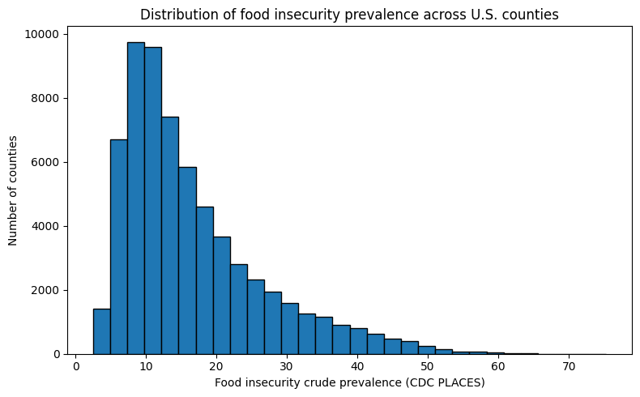

```python
import matplotlib.pyplot as plt

# Histogram of food insecurity rate distribution
plt.figure(figsize=(8, 5))

# Use dropna() to remove any missing values
plt.hist(
    target_df['food_insecurity_rate'].dropna(),
    bins=30,
    edgecolor='black'
)

plt.xlabel('Food insecurity crude prevalence (CDC PLACES)')
plt.ylabel('Number of counties')
plt.title('Distribution of food insecurity prevalence across U.S. counties')
plt.tight_layout()
plt.show()
```

### Interpretation: Distribution of County-Level Food Insecurity

The histogram shows a right-skewed distribution. Most census tracts fall between 5–20% food insecurity, clustering around 10–15%. A long right tail indicates that some communities face much higher rates, revealing substantial geographic inequality in food insecurity levels.

# EDA Step 3: Summary Statistics for USDA County-Level Food Access Rates

Next, I summarize key county-level food access indicators from the USDA Food Access Atlas.  
These variables quantify structural barriers that may contribute to food insecurity, including:

- **Low-access rate:** Share of residents living far from a supermarket
- **Low-income low-access rate:** Share of low-income residents who also lack supermarket access
- **No-vehicle low-access rate:** Share of low-access households without a vehicle available

The table below provides descriptive statistics for each access-related rate.

```python
# Summary statistics for USDA county-level food access indicators
fa_county[['low_access_rate_county',
           'low_income_low_access_rate_county',
           'no_vehicle_low_access_rate_county']].describe()
```

|  | low_access_rate_county | low_income_low_access_rate_county | no_vehicle_low_access_rate_county |
| --- | --- | --- | --- |
| count | 3142.000000 | 3142.000000 | 3142.000000 |
| mean | 0.642301 | 0.223092 | 0.012149 |
| std | 0.195047 | 0.108697 | 0.010575 |
| min | 0.000000 | 0.000000 | 0.000000 |
| 25% | 0.518202 | 0.142653 | 0.006275 |
| 50% | 0.658793 | 0.209274 | 0.010071 |
| 75% | 0.782370 | 0.295790 | 0.015252 |
| max | 1.000000 | 0.676394 | 0.182296 |

### Interpretation: USDA County-Level Food Access Indicators

Across U.S. counties, food access barriers are both common and unevenly distributed. On average, about two-thirds of residents live far from a supermarket, with large variation across regions. Roughly one in five residents are both low-income and distant from food retailers, reflecting a compounded disadvantage, while a smaller but meaningful share lack both of supermarket proximity and vehicle access as high as 18% in some counties. Together, these indicators show that physical, economic, and transportation barriers significantly shape county-level food vulnerability.

# EDA Step 4: Relationship Between Supermarket Access and Food Insecurity

To examine whether food insecurity increases in counties where more residents live far from a supermarket, I merge the USDA Food Access Atlas data with the CDC food insecurity estimates at the county level.

I then create a scatterplot of:

- **x-axis:** County low-access rate (USDA)
- **y-axis:** Food insecurity rate (CDC PLACES)

This visualization helps assess whether counties with poorer physical access to supermarkets tend to experience higher food insecurity. Because both variables vary widely, a scatterplot provides a clear way to observe potential trends, clusters, or nonlinear patterns.

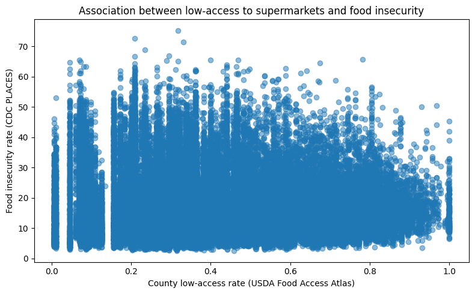

```python
# Merge USDA food access data with CDC food insecurity outcome
fa_target = fa_county.merge(
    target_df[['FIPS', 'food_insecurity_rate']],
    left_on='county_fips',
    right_on='FIPS',
    how='inner'
)

# Scatterplot: low-access rate vs. food insecurity rate
plt.figure(figsize=(8, 5))
plt.scatter(
    fa_target['low_access_rate_county'],
    fa_target['food_insecurity_rate'],
    alpha=0.5
)

plt.xlabel('County low-access rate (USDA Food Access Atlas)')
plt.ylabel('Food insecurity rate (CDC PLACES)')
plt.title('Association between low-access to supermarkets and food insecurity')
plt.tight_layout()
plt.show()
```

# EDA Step 5: Comparing Food Insecurity in Metro vs. Non-Metro Counties

To explore whether food insecurity differs between urban and rural areas, I merge the USDA Food Environment Atlas dataset (which includes the `METRO23` metro status indicator) with the CDC food insecurity data.

The `METRO23` variable categorizes each county as:

- **1: Metro (urban)**
- **0: Non-metro (rural)**

By grouping counties using this variable and summarizing food insecurity rates within each group, we can evaluate whether geographic classification (urban vs. rural) is associated with higher or lower food insecurity.

```python
# Ensure FIPS codes are zero-padded strings for a clean merge
fe_fixed = fe.copy()
fe_fixed['FIPS'] = fe_fixed['FIPS'].astype(str).str.zfill(5)

# Merge Food Environment Atlas with CDC food insecurity outcome
fe_target = fe_fixed.merge(
    target_df[['FIPS', 'food_insecurity_rate']],
    on='FIPS',
    how='inner'
)

# Group by metro status (METRO23) and compute summary statistics
metro_group = (
    fe_target.groupby('METRO23')['food_insecurity_rate']
    .agg(count='count', mean='mean', median='median')
    .reset_index()
)

metro_group  # Display the summary table
```

|  | METRO23 | count | mean | median |
| --- | --- | --- | --- | --- |
| 0 | 0 | 10657 | 16.419377 | 14.5 |
| 1 | 1 | 53230 | 16.673383 | 13.4 |

### Interpretation: Food Insecurity in Metro vs. Non-Metro Counties

Metro and non-metro counties show nearly identical average food insecurity rates, with only minimal differences in means and medians. This indicates that food insecurity is not primarily an urban or rural issue but a nationwide challenge.

# EDA Step 6: Food Insecurity Across County Poverty Levels

Poverty is one of the strongest known predictors of food insecurity.  
To examine this relationship, I group counties into poverty-rate bins using the `POVRATE21` variable from the USDA Food Environment Atlas.

I define four poverty categories:

- **<10%**
- **10–20%**
- **20–30%**
- **≥30%**

```python
# Ensure the poverty and food insecurity variables are present and drop missing rows
fe_target_pov = fe_target.dropna(subset=['POVRATE21', 'food_insecurity_rate']).copy()

# Define poverty-rate bins
bins = [0, 10, 20, 30, 100]
labels = ['<10%', '10–20%', '20–30%', '≥30%']

# Create a categorical poverty bin variable
fe_target_pov['poverty_bin'] = pd.cut(
    fe_target_pov['POVRATE21'],
    bins=bins,
    labels=labels,
    include_lowest=True
)

# Group by poverty bin and summarize food insecurity
poverty_summary = (
    fe_target_pov.groupby('poverty_bin')['food_insecurity_rate']
    .agg(count='count', mean='mean', median='median')
    .reset_index()
)

poverty_summary  # Display the table
```

|  | poverty_bin | count | mean | median |
| --- | --- | --- | --- | --- |
| 0 | <10% | 16302 | 11.398601 | 9.8 |
| 1 | 10–20% | 42493 | 17.764780 | 14.9 |
| 2 | 20–30% | 3942 | 25.340411 | 23.4 |
| 3 | ≥30% | 274 | 30.792336 | 29.5 |

### Interpretation: Food Insecurity Across County Poverty Levels

Food insecurity increases sharply with county poverty levels. Low-poverty counties (<10%) have the lowest rates (~11%), while moderate-poverty counties average ~18%, high-poverty counties ~25%, and very high-poverty counties (≥30%) exceed 30%. This clear, near-linear gradient is stronger than patterns seen in metro status or access measures, highlighting poverty as one of the most powerful structural predictors of food insecurity and a key variable for subsequent modeling.

### EDA Step 7: Correlation Between Access Barriers, Poverty, and Food Insecurity

To better understand how structural factors relate to food insecurity, I compute a correlation matrix between:

- **Food insecurity rate** (CDC PLACES)
- **Low-access rate** (share of residents far from supermarkets)
- **Low-income low-access rate** (share of low-income residents who also lack access)
- **No-vehicle low-access rate** (share of low-access households without a vehicle)
- **County poverty rate (`POVRATE21`)**

I first merge the USDA access dataset with the Food Environment Atlas poverty variable so that all of these indicators are available in a single DataFrame.  
Then I visualize the correlations using a heatmap. This helps identify which predictors have the strongest linear relationships with food insecurity and motivates which variables should be prioritized in the modeling section.

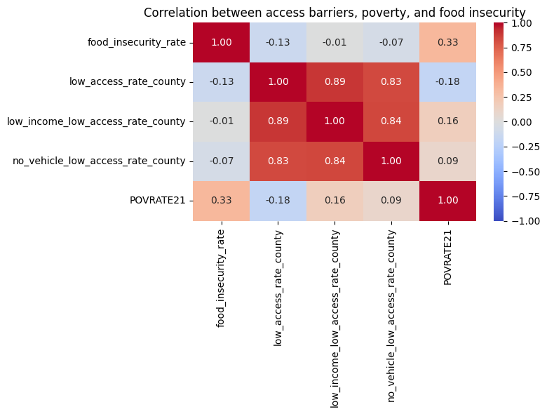

```python
import seaborn as sns
import matplotlib.pyplot as plt


# Merge fa_target (access + food insecurity) with fe_target (poverty + FI)
# Both DataFrames already contain FIPS and food_insecurity_rate
corr_df = fa_target.merge(
    fe_target[['FIPS', 'POVRATE21']],  # keep only FIPS + poverty rate
    on='FIPS',
    how='inner'
)

# Select only the numeric columns we care about for correlation
corr_cols = [
    'food_insecurity_rate',
    'low_access_rate_county',
    'low_income_low_access_rate_county',
    'no_vehicle_low_access_rate_county',
    'POVRATE21'
]

corr_matrix = corr_df[corr_cols].corr()

# Plot the correlation heatmap
plt.figure(figsize=(8, 6))

sns.heatmap(
    corr_matrix,
    annot=True,        # show correlation values in each cell
    fmt=".2f",         # format to 2 decimal places
    cmap='coolwarm',   # diverging colormap to highlight positive vs negative
    vmin=-1, vmax=1    # fix scale so colors are comparable
)

plt.title("Correlation between access barriers, poverty, and food insecurity")
plt.tight_layout()
plt.show()
```

### Interpretation: Correlation Between Access Barriers, Poverty, and Food Insecurity

The heatmap shows that poverty (POVRATE21) has the strongest correlation with food insecurity (r = 0.33), confirming it as a key structural driver. Supermarket access variables are strongly correlated with each other (r = 0.83–0.89) but only weakly related to food insecurity (–0.13 to –0.01). This suggests that access barriers cluster geographically but do not independently explain much variation in food insecurity. Poverty emerges as the most influential linear predictor for modeling.

## Modeling Step 1 — Prepare the Modeling Dataset

Before fitting a linear regression model, I first prepare a unified county-level dataset that contains:

- the **food insecurity outcome** from CDC PLACES,
- **food access barriers** from the USDA Food Access Research Atlas, and
- **socioeconomic indicators** from the USDA Food Environment Atlas.

In this step, I:

1. Merge all three datasets using the 5-digit county FIPS identifier.
2. Select a set of predictor variables grounded in the literature and prior EDA.
3. Drop any rows with missing predictor or outcome values to ensure a clean modeling matrix.

This prepares a high-quality dataset for fitting a multiple linear regression model in the next step.

```python
# Merge USDA food access data with CDC food insecurity outcome
model_df = fa_county.merge(
    target_df[['FIPS', 'food_insecurity_rate']],
    left_on='county_fips',
    right_on='FIPS',
    how='inner'
)

# Merge socioeconomic data (Food Environment Atlas)
model_df = model_df.merge(
    fe_clean,
    on='FIPS',
    how='inner'
)

# Select predictor variables for the model
predictors = [
    'low_access_rate_county',
    'low_income_low_access_rate_county',
    'no_vehicle_low_access_rate_county',
    'POVRATE21',
    'MEDHHINC21',
    'PCT_NHWHITE20',
    'PCT_NHBLACK20',
    'PCT_HISP20',
    'PCT_65OLDER20'
]

# Remove rows with missing values in predictors or the outcome
model_df = model_df.dropna(subset=predictors + ['food_insecurity_rate'])

# Display the first few rows to confirm structure
model_df.head()
```

|  | county_fips | total_pop | total_low_access | total_low_income_low_access | total_no_vehicle_low_access | low_access_rate_county | low_income_low_access_rate_county | no_vehicle_low_access_rate_county | FIPS | food_insecurity_rate | ... | PCT_65OLDER20 | PCT_18YOUNGER20 | MEDHHINC21 | POVRATE21 | CHILDPOVRATE21 | DEEPPOVRATE21 | DEEPCHILDPOVRATE21 | PERPOV17_21 | METRO23 | POPLOSS15 |
| --- | --- | --- | --- | --- | --- | --- | --- | --- | --- | --- | --- | --- | --- | --- | --- | --- | --- | --- | --- | --- | --- |
| 0 | 01001 | 54571 | 37424.108778 | 12068.104362 | 833.360281 | 0.685787 | 0.221145 | 0.015271 | 01001 | 11.2 | ... | 15.718051 | 24.28705 | 66444 | 10.7 | 16.1 | 6.250216 | 8.592895 | 0 | 1 | 0 |
| 1 | 01001 | 54571 | 37424.108778 | 12068.104362 | 833.360281 | 0.685787 | 0.221145 | 0.015271 | 01001 | 21.0 | ... | 15.718051 | 24.28705 | 66444 | 10.7 | 16.1 | 6.250216 | 8.592895 | 0 | 1 | 0 |
| 2 | 01001 | 54571 | 37424.108778 | 12068.104362 | 833.360281 | 0.685787 | 0.221145 | 0.015271 | 01001 | 10.1 | ... | 15.718051 | 24.28705 | 66444 | 10.7 | 16.1 | 6.250216 | 8.592895 | 0 | 1 | 0 |
| 3 | 01001 | 54571 | 37424.108778 | 12068.104362 | 833.360281 | 0.685787 | 0.221145 | 0.015271 | 01001 | 9.4 | ... | 15.718051 | 24.28705 | 66444 | 10.7 | 16.1 | 6.250216 | 8.592895 | 0 | 1 | 0 |
| 4 | 01001 | 54571 | 37424.108778 | 12068.104362 | 833.360281 | 0.685787 | 0.221145 | 0.015271 | 01001 | 23.0 | ... | 15.718051 | 24.28705 | 66444 | 10.7 | 16.1 | 6.250216 | 8.592895 | 0 | 1 | 0 |

5 rows × 28 columns

## Modeling Step 2 — Fit a Multiple Linear Regression Model

With the modeling dataset prepared, the next step is to fit a multiple linear regression model to evaluate how structural county-level factors relate to food insecurity.

Linear regression is used here because:

- The outcome variable (food_insecurity_rate) is continuous.
- Coefficients are easy to interpret and show how each predictor is associated with food insecurity.
- It provides a clear baseline model before exploring more complex approaches.

In this step, I:

1. Split the dataset into training (80%) and testing (20%) sets.
2. Fit a linear regression model using the selected predictors.
3. Generate predictions on the test set.
4. Compute evaluation metrics (including Mean Absolute Error (MAE) and R² )to assess model performance.

```python
from sklearn.linear_model import LinearRegression
from sklearn.model_selection import train_test_split
from sklearn.metrics import mean_absolute_error, r2_score

# X = predictor variables
X = model_df[predictors]

# y = outcome variable
y = model_df['food_insecurity_rate']

# Train-test split (80% train, 20% test)
X_train, X_test, y_train, y_test = train_test_split(
    X, y, test_size=0.2, random_state=42
)

# Initialize model
lr = LinearRegression()

# Fit model
lr.fit(X_train, y_train)

# Predict on test set
y_pred = lr.predict(X_test)

# Calculate metrics
mae = mean_absolute_error(y_test, y_pred)
r2 = r2_score(y_test, y_pred)

mae, r2
```

```
(6.466362330666086, 0.24568062344798747)
```

## Modeling Step 3 — Interpreting Model Performance

- **MAE:** ~6.47  
  The model’s predictions differ from true food insecurity rates by about 6.5 percentage points on average.
- **R²:** ~0.246  
  The model explains ~25% of the variation in food insecurity, which is expected since food insecurity is shaped by many social and economic factors that access measures alone cannot fully capture.

## Modeling Step 4 — Interpreting Linear Regression Coefficients

```python
# Create a table of model coefficients
coef_df = pd.DataFrame({
    'Predictor': predictors,
    'Coefficient': lr.coef_
})

coef_df
```

|  | Predictor | Coefficient |
| --- | --- | --- |
| 0 | low_access_rate_county | 2.112474 |
| 1 | low_income_low_access_rate_county | -1.693417 |
| 2 | no_vehicle_low_access_rate_county | 56.625196 |
| 3 | POVRATE21 | 0.395470 |
| 4 | MEDHHINC21 | -0.000086 |
| 5 | PCT_NHWHITE20 | -0.077798 |
| 6 | PCT_NHBLACK20 | 0.081191 |
| 7 | PCT_HISP20 | 0.089603 |
| 8 | PCT_65OLDER20 | -0.133535 |

- **Access indicators**
  - **no_vehicle_low_access_rate_county (+56.6):** Strongest predictor; transportation + distance barriers greatly raise food insecurity.
  - **low_access_rate_county (+2.11):** Small positive effect.
  - **low_income_low_access_rate_county (–1.69):** Negative once poverty is controlled, indicating overlap with socioeconomic factors.
- **Socioeconomic indicators**
  - **POVRATE21 (+0.40):** Poverty is a major driver; each % increase in poverty raises food insecurity ~0.4 points.
  - **MEDHHINC21 (–0.000086):** Higher income slightly reduces insecurity.
- **Demographic indicators**
  - **PCT_NHWHITE20 (–0.078):** Slight negative association.
  - **PCT_NHBLACK20 (+0.081), PCT_HISP20 (+0.090):** Small positive associations, reflecting national disparities.
  - **PCT_65OLDER20 (–0.13):** Slightly lower food insecurity in older-population counties.

Overall, transportation barriers and poverty are the strongest predictors. Access measures matter but socioeconomic inequality explains more of the variation. Food insecurity is shaped by multiple intersecting structural factors.

### Conclusion

This project combined USDA Food Access Atlas, Food Environment Atlas, and CDC PLACES data to examine structural drivers of food insecurity across U.S. counties. The EDA showed a highly uneven, right-skewed distribution of food insecurity, with higher poverty levels reliably corresponding to higher food insecurity.

Overall, food insecurity is shaped by intertwined economic, geographic, and transportation barriers. Improving supermarket access alone is insufficient. Addressing poverty and broader structural inequities is essential for meaningful reduction in food insecurity.

## Further Resources

For readers interested in deepening their understanding of food access, socioeconomic inequality, and food insecurity modeling, the following resources provide valuable background, data sources, methodological guidance, and policy context:

**• USDA Economic Research Service — Food Access Research Atlas**  
https://www.ers.usda.gov/data-products/food-access-research-atlas/  
Interactive national dataset measuring supermarket access, rurality, transportation barriers, and low-income/low-access classifications.

**• USDA Economic Research Service — Food Environment Atlas**  
https://www.ers.usda.gov/data-products/food-environment-atlas/  
County-level indicators on poverty, income, food stores, food assistance, transportation, and demographic characteristics.

**• CDC PLACES (Local Data for Better Health)**  
https://www.cdc.gov/places/  
Small-area health surveillance estimates, including food insecurity, obesity, diabetes, smoking, housing, and preventive health measures.

**• Feeding America — Map the Meal Gap Reports**  
https://www.feedingamerica.org/research/map-the-meal-gap  
Annual research estimating local food insecurity rates, meal costs, and unmet needs, including methodological white papers.

**• SNAP and Food Assistance Research Studies (USDA ERS)**  
https://www.ers.usda.gov/topics/food-nutrition-assistance/  
Analyses on how food assistance programs affect access, food security, and household outcomes.

**• “Geographies of Food Access and Food Insecurity” — Academic Literature Review**  
For deeper theoretical framing, see reviews and empirical studies on food deserts, structural determinants of hunger, and socioeconomic drivers of food insecurity in journals such as *Health & Place*, *Social Science & Medicine*, and *American Journal of Public Health*.

These resources provide foundational and advanced insights into how economic inequality, geography, transportation, retail structure, and policy environments jointly shape food insecurity. They also offer expanded datasets and modeling approaches for future research or extended versions of this project.